# Introducción a sparklyr

En esta parte veremos algunos aspectos básicos de Spark, que nos servirá para escalar análisis (tanto a máquinas con muchos cores y memoria como a clusters para los problemas más grande). En primer lugar, notamos que cuando es posible, es más simple y rápido usar máquinas más grandes y trabajar con las herramientas más flexibles que conmunmente utilizamos (pandas y dplyr), ver por ejemplo [aquí](https://h2oai.github.io/db-benchmark/), o utilizar bases de datos tradicionales apropiadamente indexadas, ver por ejemplo [esta plática](https://databricks.com/session/not-your-fathers-database-how-to-use-apache-spark-properly-in-your-big-data-architecture). .

## Conectarse a un cluster

Nos conectamos a una instancia local de Spark:

```r
library(tidyverse)
library(sparklyr)
config <- spark_config()
# configuración para modo local, ajustar la memoria del driver solamente
config$`sparklyr.shell.driver-memory` <- "2G"
# esta línea es necesaria para que la ui funcione en el contenedor:
config$`spark.env.SPARK_LOCAL_IP.local` <- "0.0.0.0"
#config$`sparklyr.log.console` <- TRUE
sc <- spark_connect(master = "local", config = config)
sc$conf
```

```
$spark.env.SPARK_LOCAL_IP.local
[1] "0.0.0.0"

$sparklyr.connect.csv.embedded
[1] "^1.*"

$sparklyr.connect.cores.local
[1] 12

$spark.sql.shuffle.partitions.local
[1] 12

$`sparklyr.shell.driver-memory`
[1] "2G"

attr(,"config")
[1] "default"
attr(,"file")
[1] "/usr/local/lib/R/site-library/sparklyr/conf/config-template.yml"
```

## Cargar datos a Spark

Normalmente los datos están en algún lugar, quizá en un sistema distribuido de archivos como HDFS. En nuestro caso están en nuestro sistema de archivos local:

```bash
wc -l ../../datos/profiles.csv
head -5 ../../datos/profiles.csv
```

```
2420410 ../../datos/profiles.csv
"age","body_type","diet","drinks","drugs","education","essay0","essay1","essay2","essay3","essay4","essay5","essay6","essay7","essay8","essay9","ethnicity","height","income","job","last_online","location","offspring","orientation","pets","religion","sex","sign","smokes","speaks","status"
22,"a little extra","strictly anything","socially","never","working on college/university","about me:<br />
<br />
i would love to think that i was some some kind of intellectual:
either the dumbest smart guy, or the smartest dumb guy. can't say i
```

Podemos cargar a Spark (sin pasar por R) como sigue:

```r
perfiles_tbl <- spark_read_csv(sc,
  path = "../../datos/profiles.csv",
  name = "perfiles",
  escape = "\"",
  options = list(multiline = TRUE),
  repartition = 8)
```

Nótese que aquí hicimos una partición de los datos explícita (si los datos están distribuidos, las particiones son implícitas). Cuando transformamos o filtramos esta tabla, puede haber 8 ejecutores trabajando en paralelo.

## Básicos de manipulación y análisis

Usamos dplyr y sparklyr para empujar código a spark, donde se ejecutan los queries y las transformaciones. Usamos el mismo código que usaríamos en dplyr aplicado a una *tibble* de *dplyr*:

```r
perfiles_tbl %>% tally()
```

| n |
| --- |
| 59946 |

- Revisa ahora [la webUI de Spark](http://0.0.0.0:4040/jobs/). Identifica el trabajo que acabamos de correr. Revisa sus dos etapas (stages), que corresponden a una agregación dentro de cada partición (donde hay una task para cada partición) y luego un shuffle (Exchange) para agrupar los resultados de cada partición. Los *shuffles* tienden a ser las operaciones más costosas (hay que mover datos), y ocurren por ejemplo con *group_by* y *joins*.

Prueba después de correr lo siguiente:

```r
perfiles_tbl %>% group_by(sex) %>% tally()
```

| sex | n |
| --- | --- |
| m | 35829 |
| f | 24117 |

```r
conteo_pets <- perfiles_tbl %>%
  mutate(pets = ifelse(is.null(pets), "No disponible", pets)) %>%
  group_by(pets) %>%
  summarise(n = n(), edad_media = mean(age), sd_edad = sd(age)) %>%
  mutate(prop = n / sum(n)) %>% arrange(desc(prop))
conteo_pets
```

```
Missing values are always removed in SQL.
Use `SUM(x, na.rm = TRUE)` to silence this warning
Use `mean(x, na.rm = TRUE)` to silence this warning
```

| pets | n | edad_media | sd_edad | prop |
| --- | --- | --- | --- | --- |
| No disponible | 19921 | 31.88319 | 9.183229 | 0.3323157508 |
| likes dogs and likes cats | 14814 | 32.15479 | 9.267910 | 0.2471224102 |
| likes dogs | 7224 | 31.83721 | 8.240287 | 0.1205084576 |
| likes dogs and has cats | 4313 | 34.54811 | 10.159560 | 0.0719480866 |
| has dogs | 4134 | 33.44098 | 10.209600 | 0.0689620659 |
| has dogs and likes cats | 2333 | 31.86369 | 10.307341 | 0.0389183599 |
| likes dogs and dislikes cats | 2029 | 30.77723 | 8.204767 | 0.0338471291 |
| has dogs and has cats | 1474 | 33.21506 | 11.957177 | 0.0245887966 |
| has cats | 1406 | 36.30654 | 11.120462 | 0.0234544423 |
| likes cats | 1063 | 32.54563 | 9.677840 | 0.0177326260 |

[output cut: 6 more lines]

Esto funciona aunque las tablas no están en la sesión de R, sino en Spark

```r
class(perfiles_tbl)
```

```
[1] "tbl_spark" "tbl_sql"   "tbl_lazy"  "tbl"
```

```r
class(conteo_pets)
```

```
[1] "tbl_spark" "tbl_sql"   "tbl_lazy"  "tbl"
```

```r
glimpse(perfiles_tbl)
```

```
Observations: ??
Variables: 31
Database: spark_connection
$ age         <int> 29, 26, 25, 21, 26, 44, 34, 40, 29, 35, 42, 40, 27, 29, 23, 35, 19, 28, 27, …
$ body_type   <chr> "athletic", "athletic", "skinny", "a little extra", "average", "athletic", "…
$ diet        <chr> "mostly anything", NA, "strictly anything", NA, NA, "mostly anything", "most…
$ drinks      <chr> "socially", "socially", "rarely", "socially", "socially", "socially", "socia…
$ drugs       <chr> "never", "sometimes", NA, "often", NA, "never", "sometimes", "never", "never…
$ education   <chr> "graduated from law school", "dropped out of college/university", "graduated…
$ essay0      <chr> "i'm white. irish white. so white that i make those poor twilight\nbastards …
$ essay1      <chr> "making money, living in the bay area, and generally participating\nin the r…
$ essay2      <chr> "blending in with walls, snow, and other white backgrounds due to\nthe pallo…
$ essay3      <chr> "i have a bit of what you yanks call an \"irish brogue\"", "smile or fitness…
$ essay4      <chr> "hah, this is where everyone tries to be all intellectual and\nshit<br />\nb…
$ essay5      <chr> "car<br />\niphone<br />\ngym<br />\nred meat<br />\nshelter<br />\njameson …
```

[output cut: 19 more lines]

Nótese: que este código no se ejecuta en la sesión de R, sino que dplyr envía código traducido en sparksql a sql, y ahí se ejecuta. Puede usarse group_by, select, mutate, filter. Las funciones que dplyr puede traducir a Spark SQL [son](https://spark.rstudio.com/dplyr/):

- Basic math operators +, -, *, /, %%, ^,
- Math functions abs, acos, asin, asinh, atan, atan2, ceiling, cos, cosh, exp, floor, log, log10, round, sign, sin, sinh, sqrt, tan, tanh,
- Logical comparisons <, <=, !=, >=, >, ==, %in%,
- Boolean operations &, &&, |, ||, !,
- Character functions paste, tolower, toupper, nchar
- Casting: as.double, as.integer, as.logical, as.character, as.date
- Basic aggregations: mean, sum, min, max, sd, var, cor, cov, n functions

Se pueden hacer también joins (left_join, anti_join, etc), muestrar con sample_n y sample_frac, usar la función ifelse, y otras.

Cuando dplyr no reconoce una función, se pasa al sql directamente, y así se pueden usar funciones de Hive, por ejemplo

```r
fechas <- perfiles_tbl %>%
  select(last_online) %>%
  mutate(fecha = substr(last_online, 0, 9),
         hora = substr(last_online, 9, 20)) %>%
  mutate(hora = regexp_replace(hora, "-", ":")) %>%
  mutate(timestamp = concat_ws(" ", fecha, hora)) %>%
  mutate(dia = dayofmonth(timestamp))
fechas
```

| last_online | fecha | hora | timestamp | dia |
| --- | --- | --- | --- | --- |
| 2012-04-11-21-46 | 2012-04-11 | 11:21:46 | 2012-04-11 11:21:46 | 11 |
| 2012-04-10-12-52 | 2012-04-10 | 10:12:52 | 2012-04-10 10:12:52 | 10 |
| 2012-06-24-00-38 | 2012-06-24 | 24:00:38 | 2012-06-24 24:00:38 | 24 |
| 2012-05-08-12-10 | 2012-05-08 | 08:12:10 | 2012-05-08 08:12:10 | 8 |
| 2012-06-20-15-05 | 2012-06-20 | 20:15:05 | 2012-06-20 20:15:05 | 20 |
| 2012-06-11-20-52 | 2012-06-11 | 11:20:52 | 2012-06-11 11:20:52 | 11 |
| 2012-06-20-22-52 | 2012-06-20 | 20:22:52 | 2012-06-20 20:22:52 | 20 |
| 2012-06-29-12-24 | 2012-06-29 | 29:12:24 | 2012-06-29 29:12:24 | 29 |
| 2012-06-29-09-47 | 2012-06-29 | 29:09:47 | 2012-06-29 29:09:47 | 29 |
| 2012-06-30-03-22 | 2012-06-30 | 30:03:22 | 2012-06-30 30:03:22 | 30 |

[output cut: 990 more lines]

```r
fechas %>% dbplyr::sql_render()
```

```
<SQL> SELECT `last_online`, `fecha`, `hora`, `timestamp`, dayofmonth(`timestamp`) AS `dia`
FROM (SELECT `last_online`, `fecha`, `hora`, concat_ws(" ", `fecha`, `hora`) AS `timestamp`
FROM (SELECT `last_online`, `fecha`, regexp_replace(`hora`, "-", ":") AS `hora`
FROM (SELECT `last_online`, SUBSTR(`last_online`, 0, 10) AS `fecha`, SUBSTR(`last_online`, 9, 12) AS `hora`
FROM `perfiles`) `dbplyr_011`) `dbplyr_012`) `dbplyr_013`
```

- concat_ws, regexp_replace y dayofmonth son funciones de Hive (ver documentación de Hive).
- Estas funciones no son funciones de R

Nótese que creamos particiones en los datos para que nos permita aprovechar paralelismo (sobre los renglones de los datos)

### Copiando datos resumidos a R

Podemos traer datos a R (por ejemplo para usar ggplot, etc.) usando *collect*:

```r
resultado <- conteo_pets %>% collect()
resultado
```

| pets | n | edad_media | sd_edad | prop |
| --- | --- | --- | --- | --- |
| No disponible | 19921 | 31.88319 | 9.183229 | 0.3323157508 |
| likes dogs and likes cats | 14814 | 32.15479 | 9.267910 | 0.2471224102 |
| likes dogs | 7224 | 31.83721 | 8.240287 | 0.1205084576 |
| likes dogs and has cats | 4313 | 34.54811 | 10.159560 | 0.0719480866 |
| has dogs | 4134 | 33.44098 | 10.209600 | 0.0689620659 |
| has dogs and likes cats | 2333 | 31.86369 | 10.307341 | 0.0389183599 |
| likes dogs and dislikes cats | 2029 | 30.77723 | 8.204767 | 0.0338471291 |
| has dogs and has cats | 1474 | 33.21506 | 11.957177 | 0.0245887966 |
| has cats | 1406 | 36.30654 | 11.120462 | 0.0234544423 |
| likes cats | 1063 | 32.54563 | 9.677840 | 0.0177326260 |

[output cut: 6 more lines]

```r
glimpse(resultado)
```

```
Observations: 16
Variables: 5
$ pets       <chr> "No disponible", "likes dogs and likes cats", "likes dogs", "likes dogs and h…
$ n          <dbl> 19921, 14814, 7224, 4313, 4134, 2333, 2029, 1474, 1406, 1063, 552, 240, 196, …
$ edad_media <dbl> 31.88319, 32.15479, 31.83721, 34.54811, 33.44098, 31.86369, 30.77723, 33.2150…
$ sd_edad    <dbl> 9.183229, 9.267910, 8.240287, 10.159560, 10.209600, 10.307341, 8.204767, 11.9…
$ prop       <dbl> 0.3323157508, 0.2471224102, 0.1205084576, 0.0719480866, 0.0689620659, 0.03891…
```

**Nota**: es mala idea hacer collect de tablas grandes. Los datos se copian en memoria, y no es un proceso rápido pues hay que traducir de spark a R. Lo mismo aplica a copiar de R a Spark.

### Evaluación perezosa

En Spark y dplyr se utiliza evaluación perezosa, es decir, se hacen cálculos solo hasta que se requieren los valores. Esto permite a Spark planear para optimizar el cálculo. Esto quiere decir que a veces corremos alguna parte de nuestro código que consiste en tranformaciones y no hay ninguna acción, el código parece correr muy rápido. En el momento que hacemos una acción (como tally o collect), entonces el cálculo se dispara.

Por ejemplo:

```r
# el archivo es de unos 5Gb, pero esto corre casi instantáneo:
system.time(
  temp <- spark_read_text(sc,
      path = "../../datos/similitud/article_categories_en.ttl",
      memory = FALSE) %>%
    mutate(url = regexp_extract(line, "(?<=/)([^/\\s]+)(?=>)"))
)
```

```
   user  system elapsed
  0.120   0.000   0.171
```

Tarda muy poco porque spark todavía no ha ejecutado código de transformación ni ha traido los datos a memoria. Acciones son *collect*, *tally* y *summarise*, por ejemplo. Se puede forzar un cómputo usando la función *compute*, que crea una tabla de Spark con el argumento que recibe y la guarda en memoria con un nombre.

## Funciones que transforman un DataFrame de Spark

Tenemos otras funciones que sirven para operar directamente en tablas de Spark sin pasar por dplyr. Muchas de estas empiezan con *sdf_"*, por ejemplo:

```r
sdf_schema(perfiles_tbl)
```

```
$age
$age$name
[1] "age"

$age$type
[1] "IntegerType"


$body_type
$body_type$name
[1] "body_type"

$body_type$type
[1] "StringType"


$diet
$diet$name
[1] "diet"

$diet$type
[1] "StringType"


$drinks
$drinks$name
[1] "drinks"

$drinks$type
[1] "StringType"


$drugs
$drugs$name
[1] "drugs"

$drugs$type
[1] "StringType"


```

[output cut: 191 more lines]

```

$speaks
$speaks$name
[1] "speaks"

$speaks$type
[1] "StringType"


$status
$status$name
[1] "status"

$status$type
[1] "StringType"
```

```r
sdf_describe(perfiles_tbl)
```

| summary | age | body_type | diet | drinks | drugs | education | essay0 | essay1 | essay2 | essay3 | essay4 | essay5 | essay6 | essay7 | essay8 | essay9 | ethnicity | height | income | job | last_online | location | offspring | orientation | pets | religion | sex | sign | smokes | … |
| --- | --- | --- | --- | --- | --- | --- | --- | --- | --- | --- | --- | --- | --- | --- | --- | --- | --- | --- | --- | --- | --- | --- | --- | --- | --- | --- | --- | --- | --- | --- |
| count | 59946 | 54650 | 35551 | 56961 | 45866 | 53318 | 54461 | 52375 | 50308 | 48470 | 49409 | 49099 | 46175 | 47496 | 40732 | 47344 | 54266 | 59946 | 59946 | 51748 | 59946 | 59946 | 24385 | 59946 | 40025 | 39720 | 59946 | 48890 | 54434 | … |
| mean | 32.3402895939679 | NA | NA | NA | NA | NA | 7.0 | NA | NA | NA | 1502.75 | 7777777.0 | 174.9161 | NA | 154.5 | 42.0 | NA | 68.29528051649066 | 20033.222533613585 | NA | NA | NA | NA | NA | NA | NA | NA | NA | NA | … |
| stddev | 9.452779096971724 | NA | NA | NA | NA | NA | NaN | NA | NA | NA | 973.8663067040225 | NaN | 509.09075800700805 | NA | 203.2591941339924 | NaN | NA | 3.9948031346551254 | 97346.1921036873 | NA | NA | NA | NA | NA | NA | NA | NA | NA | NA | … |
| min | 18 | a little extra | anything | desperately | never | college/university | ! ! ! ! ! ! ! ! ! !young man.. into having fun , great sense of\nhumor and a great a goof... im on here becuz real life datin takes\ntoo much time... so why not pick up some of the worlds computer\nlo… | ! ! ! ! ! ! ! ! ! ! currently in school and working construction..\nmy school is for construction also but it not that bad keeps my\nbody toned and helps with stamina so get at me... ! ! ! ! ! !! ! !\… | ! ! ! ! ! ! ! ! ! ! yew decide... am a all around cool guy i know\nalot but im always up to learning new things.. it keeps me active\nand my list of thhings that im good at is constantly growin..! ! !… | ! | ! ! ! ! ! ! ! ! ! ! ! ! ! ! ! ! ! ! !too many to specify.. but dean\nkoontz he's the greatest author ever.. i love movies like troy,\n300, those movie about ancient battles.. its a big interest of\nmi… | ! ! ! ! ! ! ! ! ! ! ! ! ! ! ! ! ! ! !ice cream, music, cake, music\nvideos, friends and more ice cream. ! ! ! ! ! ! ! ! ! ! ! ! ! ! ! !\n! ! ! im big on sweets but im just jokin up there... really its… | ! ! ! ! ! ! ! ! ! ! ! ! ! ! ! ! !my mother... she passed when i was\n12years old and now i just have those days when shes on my mind\nalot..! ! ! ! ! ! ! ! ! ! ! ! ! ! ! ! ! ! | ! ! ! ! ! ! ! ! ! ! ! ! ! ! ! ! ! ! ! either sitting at home... or\nout with friends.. i dont party much and clubs are a waste of time\nnow... so i just watch tv or a movie.. ! ! ! ! ! ! ! ! ! ! ! ! !… | ! | ! ! \n , , , , , , , , , ---if you can\nunderstand what that means. | asian | 1 | -1 | artistic / musical / writer | 2011-06-27-01-52 | alameda, california | doesn&rsquo;t have kids | bisexual | dislikes cats | agnosticism | f | aquarius | no | … |
| max | 110 | used up | vegetarian | very often | sometimes | working on two-year college | ~~~~~~~~~~~~~~~~~~~~~~~~~~~~~~~~~~~\n\nwhen i was 6 years old, my family was walking down a street\nin\ncairo, egypt. suddenly my dad pointed to an ornate building\nand\nsaid, "big g! did you know tha… | ~i am living on my own term's like i wanted all along, and we'll\nsee if i can swing summer classes at palomar. . i'm really into\nfocusing on my writting and hope to become a songwritter. i love\npoe… | ~~ being unique, creative, adventurous, finding humor in most\neverything ~~ | ~~~~~~~~~~~~~~~~~~~~~~~~~~~~~~~~~\n~~~~~~~~~///////////////////\\~~~~~~~~~~~~~\n~~~~~~~/////////////////////////\\\\\\\\~~~~~~~~~~\n~~~~////////////////////////////////\\\\\\\\\\\\\\\\\\\\~~~~~~\n~~~/… | ~music i'm currently listening to..... grand ole party, muse, daft\npunk, pepper, slightly stoopid, the used, my chemical romance,\ngreenday, autechre, aphex twin, boards of canada, venetian snares,\n… | ~the fam\n~the cam\n~the jam\n~chopin\n~very, very, very slow and sustained kissing\n~coffee | ~when i'll next go home (japan and hawai`i)\n~what i can do to make this world a better place. working on a few\nprojects locally and globally right now.\n~when and where my next travel destination wi… | ~watching movie while wearing high heels &amp; underwear\n~eating popcorn, yum...\n~jumping on bed\n~a variety pack of things and nonsense :-) | ~~ i want to feel worshiped like a goddess ~~ :) | ~you're silly\n~you believe in magic\n~you are looking for someone amazing to create a life\ntogether\n~you go deep\n~you love love\n~meditation does not weird you out.\n~you laugh easily\n~you are pa… | white, other | NA | 1000000 | unemployed | 2012-07-01-08-57 | woodside, california | wants kids | straight | likes dogs and likes cats | other but not too serious about it | m | virgo but it doesn&rsquo;t matter | yes | … |

```r
perfiles_part <- sdf_random_split(perfiles_tbl, entrena = 0.9, prueba = 0.1)
perfiles_part$prueba %>% tally()
```

| n |
| --- |
| 6033 |

```r
perfiles_part$entrena %>% tally()
```

| n |
| --- |
| 53913 |

Para crear dataframes en spark directamente

```r
ejemplo <- sdf_along(sc, along = 1:10)
glimpse(ejemplo)
```

```
Observations: ??
Variables: 1
Database: spark_connection
$ id <int> 1, 2, 3, 4, 5, 6, 7, 8, 9, 10
```

```r
sdf_register(ejemplo, "ejemplo")
```

| id |
| --- |
| 1 |
| 2 |
| 3 |
| 4 |
| 5 |
| 6 |
| 7 |
| 8 |
| 9 |
| 10 |

- sdf_broadcast, sdf_checkpoint, sdf_bind_rows, sdf_bind_cols, sdf_repartition etc. son otras funciones útiles

## Transformadores y Estimadores

El paquete Spark ML de Spark provee los siguientes conceptos útiles para trabajar con modelos y predicciones a partir de DataFrames de Spark.

- Transformadores: toman un DataFrame y producen otro (por ejemplo, agregar una columna de predicciones)
- Estimadores: se ajustan con un DataFrame y resultan en un Transformador
- Parámetros: estimadores y transformadores tiene parámetros que se pueden ajustar con un DataFrame o directamente
- Pipeline: cadena de estimadores y transformadores. Es un estimador, y cuando se ajusta produce un transformador.
- Los transformadores definidos en Spark comienzan con "*ft_*, puedes ver por ejemplo [aqui](https://spark.apache.org/docs/2.4.0/ml-features.html). Todos los transformadores y estimadores de spark pueden accederse desde sparklyr.
- Los estimadores de machine learning de Spark comienzan con *ml_*, como ml_linear_regression, ml_gradient_boosted_trees, ml_bisecting_kmeans, etc.

Por ejemplo:

```r
# ver https://therinspark.com/modeling.html
# definir algunas transformaciones:
trans_df <- perfiles_tbl %>%
  mutate(
    height = as.numeric(height),
    income = ifelse(income == "-1", NA, as.numeric(income))
  ) %>%
  mutate(sex = ifelse(is.na(sex), "missing", sex)) %>%
  mutate(drinks = ifelse(is.na(drinks), "missing", drinks)) %>%
  mutate(drugs = ifelse(is.na(drugs), "missing", drugs)) %>%
  mutate(job = ifelse(is.na(job), "missing", job)) %>%
  mutate(not_working = ifelse(job %in% c("student", "unemployed", "retired"), 1 , 0))


# Un pipeline que comienza con dplyr
pipeline_perfiles <- ml_pipeline(sc) %>%
  ft_dplyr_transformer(trans_df) %>%
  ft_string_indexer(input_col = "sex", output_col = "sex_indexed") %>%
  ft_string_indexer(input_col = "drinks", output_col = "drinks_indexed") %>%
  ft_string_indexer(input_col = "drugs", output_col = "drugs_indexed") %>%
  ft_one_hot_encoder_estimator(
    input_cols = c("sex_indexed", "drinks_indexed", "drugs_indexed"),
    output_cols = c("sex_encoded", "drinks_encoded", "drugs_encoded")
  ) %>%
  ft_vector_assembler(
    input_cols = c("age", "sex_encoded", "drinks_encoded",
                   "drugs_encoded"),
    output_col = "features"
  ) %>%
  ft_standard_scaler(input_col = "features", output_col = "features_scaled",
                     with_mean = TRUE) %>%
  ml_logistic_regression(features_col = "features_scaled",
                         label_col = "not_working")
pipeline_perfiles
```

```
Pipeline (Estimator) with 8 stages
<pipeline_51b430706be5>
  Stages
  |--1 SQLTransformer (Transformer)
  |    <dplyr_transformer_51b49f2299a>
  |     (Parameters -- Column Names)
  |--2 StringIndexer (Estimator)
  |    <string_indexer_51b4378d018b>
  |     (Parameters -- Column Names)
  |      input_col: sex
  |      output_col: sex_indexed
  |     (Parameters)
  |      handle_invalid: error
  |      string_order_type: frequencyDesc
  |--3 StringIndexer (Estimator)
  |    <string_indexer_51b42f8a8192>
  |     (Parameters -- Column Names)
  |      input_col: drinks
  |      output_col: drinks_indexed
  |     (Parameters)
  |      handle_invalid: error
  |      string_order_type: frequencyDesc
  |--4 StringIndexer (Estimator)
  |    <string_indexer_51b424a986e8>
  |     (Parameters -- Column Names)
  |      input_col: drugs
  |      output_col: drugs_indexed
  |     (Parameters)
  |      handle_invalid: error
  |      string_order_type: frequencyDesc
  |--5 OneHotEncoderEstimator (Estimator)
  |    <one_hot_encoder_estimator_51b469d45e73>
  |     (Parameters -- Column Names)
  |      input_cols: sex_indexed, drinks_indexed, drugs_indexed
  |      output_cols: sex_encoded, drinks_encoded, drugs_encoded
  |     (Parameters)
  |      drop_last: TRUE
  |      handle_invalid: error
  |--6 VectorAssembler (Transformer)
  |    <vector_assembler_51b458775c1f>
```

[output cut: 14 more lines]

```
  |      features_col: features_scaled
  |      label_col: not_working
  |      prediction_col: prediction
  |      probability_col: probability
  |      raw_prediction_col: rawPrediction
  |     (Parameters)
  |      aggregation_depth: 2
  |      elastic_net_param: 0
  |      family: auto
  |      fit_intercept: TRUE
  |      max_iter: 100
  |      reg_param: 0
  |      standardization: TRUE
  |      threshold: 0.5
  |      tol: 1e-06
```

Ahora particionamos:

```r
perfiles_part <- sdf_random_split(perfiles_tbl, entrena = 0.8, prueba = 0.2)
```

ajustamos

```r
reg_perfiles <- ml_fit(pipeline_perfiles, perfiles_part$entrena)
reg_perfiles
```

```
PipelineModel (Transformer) with 8 stages
<pipeline_51b430706be5>
  Stages
  |--1 SQLTransformer (Transformer)
  |    <dplyr_transformer_51b49f2299a>
  |     (Parameters -- Column Names)
  |--2 StringIndexerModel (Transformer)
  |    <string_indexer_51b4378d018b>
  |     (Parameters -- Column Names)
  |      input_col: sex
  |      output_col: sex_indexed
  |     (Transformer Info)
  |      labels:  chr [1:2] "m" "f"
  |--3 StringIndexerModel (Transformer)
  |    <string_indexer_51b42f8a8192>
  |     (Parameters -- Column Names)
  |      input_col: drinks
  |      output_col: drinks_indexed
  |     (Transformer Info)
  |      labels:  chr [1:7] "socially" "rarely" "often" "not at all" "missing" "very often" "desperately"
  |--4 StringIndexerModel (Transformer)
  |    <string_indexer_51b424a986e8>
  |     (Parameters -- Column Names)
  |      input_col: drugs
  |      output_col: drugs_indexed
  |     (Transformer Info)
  |      labels:  chr [1:4] "never" "missing" "sometimes" "often"
  |--5 OneHotEncoderModel (Transformer)
  |    <one_hot_encoder_estimator_51b469d45e73>
  |     (Parameters -- Column Names)
  |      input_cols: sex_indexed, drinks_indexed, drugs_indexed
  |      output_cols: sex_encoded, drinks_encoded, drugs_encoded
  |--6 VectorAssembler (Transformer)
  |    <vector_assembler_51b458775c1f>
  |     (Parameters -- Column Names)
  |      input_cols: age, sex_encoded, drinks_encoded, drugs_encoded
  |      output_col: features
  |--7 StandardScalerModel (Transformer)
  |    <standard_scaler_51b4602f991c>
  |     (Parameters -- Column Names)
  |      input_col: features
  |      output_col: features_scaled
  |     (Transformer Info)
  |      mean:  num [1:11] 32.3425 0.5974 0.6965 0.0992 0.0867 ...
  |      std:  num [1:11] 9.471 0.49 0.46 0.299 0.281 ...
  |--8 LogisticRegressionModel (Transformer)
  |    <logistic_regression_51b472bfc9c8>
  |     (Parameters -- Column Names)
  |      features_col: features_scaled
  |      label_col: not_working
  |      prediction_col: prediction
  |      probability_col: probability
  |      raw_prediction_col: rawPrediction
  |     (Transformer Info)
  |      coefficient_matrix:  num [1, 1:11] -1.2755 -0.1051 0.1039 0.199 -0.0206 ...
  |      coefficients:  num [1:11] -1.2755 -0.1051 0.1039 0.199 -0.0206 ...
  |      intercept:  num -2.8
  |      intercept_vector:  num -2.8
  |      num_classes:  int 2
  |      num_features:  int 11
  |      threshold:  num 0.5
  |      thresholds:  num [1:2] 0.5 0.5
```

Predicciones para el conjunto de validación

```r
preds <- ml_transform(reg_perfiles, perfiles_part$prueba)
colnames(preds)
```

```
 [1] "age"             "body_type"       "diet"            "drinks"          "drugs"
 [6] "education"       "essay0"          "essay1"          "essay2"          "essay3"
[11] "essay4"          "essay5"          "essay6"          "essay7"          "essay8"
[16] "essay9"          "ethnicity"       "height"          "income"          "job"
[21] "last_online"     "location"        "offspring"       "orientation"     "pets"
[26] "religion"        "sex"             "sign"            "smokes"          "speaks"
[31] "status"          "not_working"     "sex_indexed"     "drinks_indexed"  "drugs_indexed"
[36] "sex_encoded"     "drinks_encoded"  "drugs_encoded"   "features"        "features_scaled"
[41] "rawPrediction"   "probability"     "prediction"
```

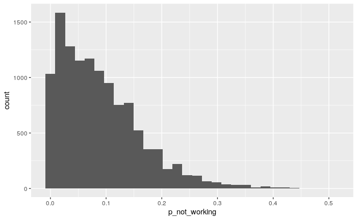

```r
preds_df <- preds %>% select(not_working, probability, prediction) %>%
  sdf_separate_column("probability", into = c("p_working", "p_not_working")) %>%
  collect
ggplot(preds_df, aes(x = p_not_working)) + geom_histogram()
```